# 第一讲：什么是神经网络？

### 1. 计算机擅长干什么以及人脑擅长干什么？

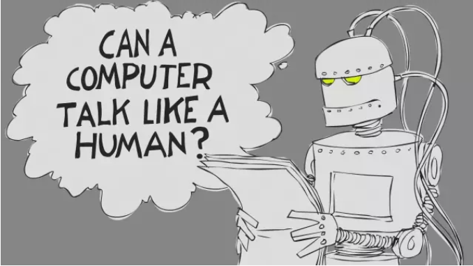

计算机是人类创造的工具。它的核心是一堆逻辑电路。

人脑是人类的思维器官。它的核心是一堆神经元组成的网络。

尺有所短，寸有所长。就像人类发明的菜刀更适合切菜，而人类的手指更擅长敲击键盘；人类和人类的创造物通常在“擅长的工作”方面有所不同。

下面分别列举了计算机擅长干的事情和人脑擅长干的事情。你能在后面的空白处再补充一些吗？

注意，如果你在输入的时候每一行前面加上 “#”，编译器就知道你写的是自己的想法，而不是计算机可执行的代码。我们管这样的东西叫做“注释”。

```python
# 更适合计算机完成的工作

# 1. 从1加到1000

a = sum(range(1,1001))
print(a)

# 2. 计算123456 * 654321

a = 123456*654321
print(a)

# 3.

# 4.

# 5.
```

```
500500
80779853376
```

```python
# 更适合人类完成的工作

# 1. 爱。

# 2. 从你妈妈的高中毕业照中认出你妈妈。

# 3.

# 4.

# 5.
```

由此可见，现在（2020年）大家普遍认为计算机擅长的仅是具体的（算术运算、程序性控制）和低级抽象的（基本特征提取）计算，而人脑擅长的是高级抽象的（推理、联想、思考、意识等）计算。

然而，总有一些人梦想着让计算机干人脑擅长的事情。于是就有了这样一门学科“人工智能”，也叫Artificial Intelligence，简称AI。

### 2. 人工智能和神经网络是什么关系呢?

自图灵提出“有智能的机器”，这就成为了人们尤其是计算机科学家的理想之一。大家应该在很多影视剧里都见过“有智能的机器”，从“银河系漫游指南”里的马文，到美剧“疑犯追踪”里的机器宝宝。

（我还用疑犯追踪剪过一个视频，试图介绍AI，然而并没有人看：https://www.bilibili.com/video/BV1cE411F7ck/ ）

就如何实现“有智能的机器”，学界一直就有两派观点:

一派是写实的符号派：认为实现人工智能必须用逻辑和符号系统，这一派的视角是自上而下的；

还有一派是写意的仿生派：认为通过仿造大脑可以达到人工智能，这一派的视角是自下向上的，如果能造一台机器，模拟大脑中的神经网络，这台机器不就有智能了吗？

这两派一直是人工智能领域里两个阶级、两条路线的斗争，这斗争有时还你死我活。

而神经网络呢，就是第二派里的集大成者。

下图说明了“人工智能”、“机器学习”、“神经网络”、“深度学习”之间的关系。

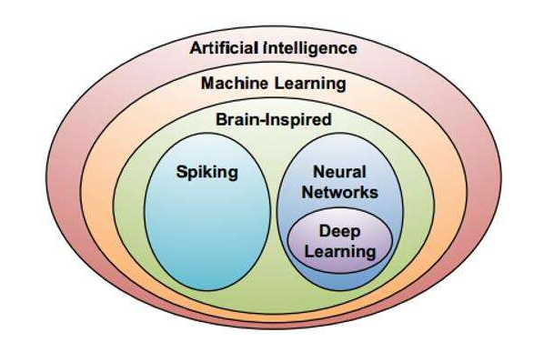

机器学习（Machine Learning）可以被看成是“人工智能”的核心算法，让机器（广义上的计算机）通过学习来获得类似人类的智能。

神经网络（Neural Network）就是实现机器学习任务的方法之一。它是由许多简单元组成的网络结构，这种网络结构类似于生物神经系统，用来模拟生物与自然环境之间的交互。

除了神经网络可以实现机器学习任务外，常见的还有线性回归、决策树、支持向量机、贝叶斯分类器、强化学习、概率图模型、聚类等多种方法，可见神经网络方法只是机器学习方法中的一种。

深度学习（Deep Learning），本质上就是深层的神经网络。早在上世纪40年代，神经网络就被提了出来，但在应用上一般采用很浅层的、很小的网络。现如今，随着数据量越来越大，计算资源越来越丰富，以及算法上的改进和优化，神经网络的层数变得越来越多，学习的效果变得也越来越好。

神经网络也是一个比较大的概念，针对语音、文本、图像等不同的学习任务，衍生出了更适用于具体学习任务的神经网络模型，如递归神经网络（Recurrent Neural Network，RNN）、卷积神经网络（Convolutional Neural Network，CNN）等。

### 3. 神经网络发展简史

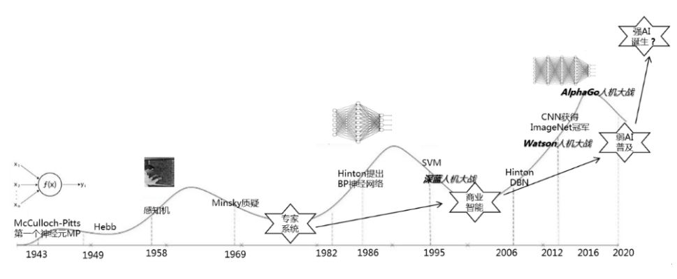

神经网络的大致发展过程就如上图，俗称三起两落。（希望我们不要赶上第三落）

1943年，Warren McCulloch（麦卡洛克） 和 Walter Pitts（皮茨） 发表题为 “A Logical Calculus of the Ideas Immanent in Nervous Activity”的论文，首次提出神经元的M-P模型。该模型借鉴了已知的神经细胞生物过程原理，是第一个神经元数学模型，是人类历史上第一次对大脑工作原理描述的尝试。

生物神经元可视为一个只有激活和抑制两种状态的细胞，在计算机上也就是1和0，兴奋状态在不同的神经元之间传递。M-P模型的工作原理是神经元的输入信号加权求和，与阈值比较再决定神经元是否输出。这篇论文从原理上证明了人工神经网络可以计算任何算术和逻辑函数。神经元计算模型可以说是神经网络理论的基础，所以这篇论文被称为开山大作。

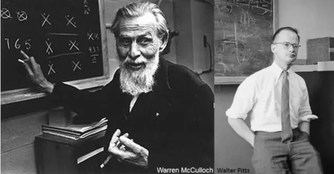

话说这两位开山老祖的经历十分传奇。我们稍微说两句。

皮茨打小就喜欢数学和哲学，但家里很穷，连高中都读不起。他十五岁时，他爸强行要他退学，皮茨一怒就离家出走了。他初中时和偶像罗素有过通信，打听到罗素那时要到芝加哥大学任教，就只身来到芝加哥，还真见到了罗素。老罗遂把他推荐给那时也在芝加哥任教的卡尔纳普。卡尔纳普想看看这孩子到底有多聪明，就把自己的《语言的逻辑句法》一书送给皮茨，没过一个月，皮茨就看完了，把写满笔记的原书还给卡尔纳普。老卡惊为天人，于是给他在芝加哥大学安排了份打扫卫生的工作(￣▽￣") 。一年之后，他见到了麦卡洛克。

麦卡洛克比皮茨大25岁，来自一个截然不同的世界。从小家境优越，本科在耶鲁学哲学和心理学，后在哥伦比亚取得了心理学硕士和医学博士（MD)。见到皮茨时在伊利诺伊大学芝加哥分校做精神病学系的教授。麦卡洛克本职从事神经科学的研究，不懂数学，然而他的内心是一个坚定的机械唯物主义者。在当时弗洛伊德主导的玄学思潮中，他仍然坚信人脑的神秘功能来自于机械放电。

麦卡洛克向皮茨解释他正在试图用莱布尼茨的逻辑演算来建立一个大脑模型。他的灵感来自于《数学原理》，书中论述了所有的数学都可以自下而上的用无可争论的基本逻辑来建立。最基本的结构是命题（即最简单的陈述/判断），是或非。从命题入手，罗素和怀特海德采用了与、或、非三种基本逻辑运算来将命题连接成越来越复杂的网络。就是利用这些简单的命题，他们完整的推导出了整个复杂的现代数学。

这启发了麦卡洛克对于神经元的思考。他知道大脑里的每一个神经细胞只会在最小阙值达到时被激发：必须有足够多的相邻神经细胞通过神经元的突触向它传递信号，它才会发放出自己的电脉冲。对于麦卡洛克来说，这种设置就是二元的，神经元只有激发和不激发两种状态。他发现神经元的信号就是一个命题，而神经元的工作类似于逻辑门，它接受多个输入然后产生单一的输出。通过改变神经元的激发阙值，就可以让它执行“与”、“或”以及“非”的函数（功能）。

数学和逻辑天才皮茨的适时出现给了麦卡洛克最强助力。皮茨将麦卡洛克的神经网络抽象成了数学模型，提出了阈值逻辑单元（threshold logic units，TLU)这个函数模型来描述神经元。

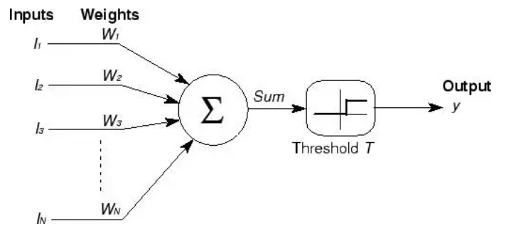

麦卡洛克和皮茨将他们的发现记录了下来。就是我们的开山大作。他们的模型是对生物学大脑极大的过度简化，但却成功的给我们提供了基本原理的证明。他们说，“思想”本无需笼罩一层弗洛伊德式的神秘主义或牵扯上自我与本我之间的挣扎。麦卡洛克向一群研究哲学的学生宣布：“我们知道了我们是怎么知道的（weknowhowweknow），这是科学史上的第一次。”

那一年是1943年。在这之后，“神经网络这门学科经历了3起2落。

1958，Rosenblatt提出感知器，并提出一种接近于人类学习过程的学习算法。这是第一起。

1969，Marvin Minsky 和 Seymour Papert 发表《Perceptrons: an introduction to computational geometry》一书，从数学的角度证明了单层神经网络具有有限的功能，甚至在面对简单的“异或”逻辑问题时也显得无能为力。往后十多年，神经网络的研究一直没有太大进展。这是第一落。

1986，Hinton等人发表文章《Learning representations by back-propagating errors》，重新发现BP神经网络学习算法。BP算法引入了sigmod函数神经元，将改进的反向传播算法引入多层感知器，神经网络重新成为热点。反向传播算法是神经网络中极为重要的学习算法，直到现在仍然占据着重要地位。这是第二起。

1995-2006，计算机性能仍然无法支持大规模的神经网络训练，SVM和线性分类器等简单的方法反而更流行。这是第二落。

2006，随着大规模并行计算和GPU的优化，计算机处理速度和存储能力大大提高，在此支持下，神经网络迎来第三次高潮。G. E. Hinton 和他的学生 R. R. Salakhutdinov 在《Science》杂志上发表题为《Reducing the Dimensionality of Data with Neural Networks》的文章，掀起了深度学习在学术界和工业界的研究热潮。文章摘要阐述了两个重要观点：一是多隐层的神经网络可以学习到能刻画数据本质属性的特征，对数据可视化和分类等任务有很大帮助；二是可以借助于无监督的“逐层初始化”策略来有效克服深层神经网络在训练上存在的难度。这篇文章是一个分水岭，拉开了深度学习大幕，标志着深度学习的诞生。2014年至今， 深度学习在很多领域都取得了突破性进展，发展出了包括注意力(attention)，RNN--CNN， 以及深度残差网络等多种模型。

从此，历史这样写就：从感知机提出，到BP算法应用以及2006年以前的历史被称为浅层学习，以后的历史被称为深度学习。

这就是我们所处的时代。

### 4. 我想用神经网络实现的功能

下面看似一个文本框，实则是一个许愿池。

请你把你希望用神经网络实现的功能写在这里。

也许现在你会觉得自己的想法仿佛天方夜谭。然而当我们结束这一门课程的时候，你能感觉到它并非遥不可及。

```python
# 我想用神经网络实现的功能
```